# Project: Investigate a Dataset (No_show_appointments)

## Amos Omofaiye (Udacity Bertelsmann Scholarship Recipient)

- Introduction
- Data Wrangling
- Exploratory Data Analysis
- Conclusions

## Introduction

> The *no_show_appointments dataset* contains information from over 100 thousand medical appointments in Brazil. It is focused on the question of whether or not patients show up for their appointment. A number of characteristics about the patient are included in each row. The dataset consists of 14 variables in total. The *independent variables* are 13 and the *dependent variable* is **No-show** The independent variables are:
> 1. PatientId: This is a number identifying the patient.
> 2. AppointmentId: This is a number identifying the appointment(s) made by patients. A patient may make more than one appointment.
> 3. Gender: This variable stores the sex of the patient making appointment.
> 4. ScheduledDay: This variable captures the day the appointment was made by the patient.
> 5. AppointmentDay: This is the actual day the appointment is scheduled to occur. It will be later than the ScheduledDay.
> 6. Age: This is the age of the patient who makes the appointment.
> 7. Neighbourhood: This is the place where the hospital is located. As such it is the location where the appointment takes place.
> 8. Scholarship: This captures whether the patient is a beneficiary of the **Bolsa Familia Programme**. This is a federal conditional cash transfer programme in Brazil tied to some responsibilities on the part of the receiver. You can click [here](https://en.wikipedia.org/wiki/Bolsa_Fam%C3%ADlia) to read more on the programme online. Values here are either True or False.
> 9. Hipertension: This variable captures whether a patient has hypertension or not. It can be True or False.
> 10. Diabetes: This variable captures whether a patient has diabetes or not. It can be True or False.
> 11. Alcoholism: This variable captures whether a patient is suffering from alcoholism or not. It can be True or False.
> 12. Handcap: This variable captures whether a patient suffers from one form of physical disability or not. It can be True or False.
> 13. SMS_received: This variable notes whether a patient receives at least an SMS reminding him or her of the appointment before the appointment time.

The *dependent variable* is:

- No-show: This captures whether a patient shows up on the day of the appointment or not. If a patient did not show, he/she gets a 'Yes' and a 'No' if he/she shows up.

Over the course of this analysis, I will be exploring the following questions:

1. How does each independent variable except the identification variables correlates with the dependent variable?
2. What factors are important to predict whether a patient will show up for their scheduled appointment?

I will walk you through the whole process of analyzing the dataset in this report. Please sit tight. It promises to be a fun ride. **Shall we begin?**

```python
# Now I will import the libraries that I need for this analysis.
import pandas as pd
import numpy as np
import matplotlib.pyplot as plt
import seaborn as sns
sns.set_style('darkgrid')

# I want my visualizations to be plotted inline with this notebook, so I include the following line
%matplotlib inline
```

## Data Wrangling

> **Tip**: In this section of the report, you will load in the data, check for cleanliness, and then trim and clean your dataset for analysis. Make sure that you document your steps carefully and justify your cleaning decisions.

> Now I will load the data, assess, and clean it.

### General Properties

```python
# Load your data and print out a few lines. Perform operations to inspect data
#   types and look for instances of missing or possibly errant data.
dap = pd.read_csv('noshow.csv')
```

```python
dap.tail(2)
```

|  | PatientId | AppointmentID | Gender | ScheduledDay | AppointmentDay | Age | Neighbourhood | Scholarship | Hipertension | Diabetes | Alcoholism | Handcap | SMS_received | No-show |
| --- | --- | --- | --- | --- | --- | --- | --- | --- | --- | --- | --- | --- | --- | --- |
| 110525 | 9.213493e+13 | 5630323 | F | 2016-04-27T15:09:23Z | 2016-06-07T00:00:00Z | 38 | MARIA ORTIZ | 0 | 0 | 0 | 0 | 0 | 1 | No |
| 110526 | 3.775115e+14 | 5629448 | F | 2016-04-27T13:30:56Z | 2016-06-07T00:00:00Z | 54 | MARIA ORTIZ | 0 | 0 | 0 | 0 | 0 | 1 | No |

> The column headings start with capital letter. Some are a miss of upper and lower case letters in a quasi camelcase manner. The No-show variable also uses a dash to separate the two words.

> I like having column names in lowercase letters and if they are more than a word the words should be separated using an underscore. So I will effect this change immediately.

```python
# Changing column names to  lower case and underscore separated
dap.rename(columns=lambda x: x.strip().lower().replace("-", "_"), inplace=True)
```

> Now we can check whether the change has been effected.

```python
dap.head()
```

|  | patientid | appointmentid | gender | scheduledday | appointmentday | age | neighbourhood | scholarship | hipertension | diabetes | alcoholism | handcap | sms_received | no_show |
| --- | --- | --- | --- | --- | --- | --- | --- | --- | --- | --- | --- | --- | --- | --- |
| 0 | 2.987250e+13 | 5642903 | F | 2016-04-29T18:38:08Z | 2016-04-29T00:00:00Z | 62 | JARDIM DA PENHA | 0 | 1 | 0 | 0 | 0 | 0 | No |
| 1 | 5.589978e+14 | 5642503 | M | 2016-04-29T16:08:27Z | 2016-04-29T00:00:00Z | 56 | JARDIM DA PENHA | 0 | 0 | 0 | 0 | 0 | 0 | No |
| 2 | 4.262962e+12 | 5642549 | F | 2016-04-29T16:19:04Z | 2016-04-29T00:00:00Z | 62 | MATA DA PRAIA | 0 | 0 | 0 | 0 | 0 | 0 | No |
| 3 | 8.679512e+11 | 5642828 | F | 2016-04-29T17:29:31Z | 2016-04-29T00:00:00Z | 8 | PONTAL DE CAMBURI | 0 | 0 | 0 | 0 | 0 | 0 | No |
| 4 | 8.841186e+12 | 5642494 | F | 2016-04-29T16:07:23Z | 2016-04-29T00:00:00Z | 56 | JARDIM DA PENHA | 0 | 1 | 1 | 0 | 0 | 0 | No |

> Good! It has been effected. I want to check for missing values and duplicates, next.

```python
# Checking for duplicates
sum(dap.duplicated())

# Checking for missing values
dap.info()
dap.isnull()
```

```
<class 'pandas.core.frame.DataFrame'>
RangeIndex: 110527 entries, 0 to 110526
Data columns (total 14 columns):
 #   Column          Non-Null Count   Dtype
---  ------          --------------   -----
 0   patientid       110527 non-null  float64
 1   appointmentid   110527 non-null  int64
 2   gender          110527 non-null  object
 3   scheduledday    110527 non-null  object
 4   appointmentday  110527 non-null  object
 5   age             110527 non-null  int64
 6   neighbourhood   110527 non-null  object
 7   scholarship     110527 non-null  int64
 8   hipertension    110527 non-null  int64
 9   diabetes        110527 non-null  int64
 10  alcoholism      110527 non-null  int64
 11  handcap         110527 non-null  int64
 12  sms_received    110527 non-null  int64
 13  no_show         110527 non-null  object
dtypes: float64(1), int64(8), object(5)
memory usage: 11.8+ MB
```

|  | patientid | appointmentid | gender | scheduledday | appointmentday | age | neighbourhood | scholarship | hipertension | diabetes | alcoholism | handcap | sms_received | no_show |
| --- | --- | --- | --- | --- | --- | --- | --- | --- | --- | --- | --- | --- | --- | --- |
| 0 | False | False | False | False | False | False | False | False | False | False | False | False | False | False |
| 1 | False | False | False | False | False | False | False | False | False | False | False | False | False | False |
| 2 | False | False | False | False | False | False | False | False | False | False | False | False | False | False |
| 3 | False | False | False | False | False | False | False | False | False | False | False | False | False | False |
| 4 | False | False | False | False | False | False | False | False | False | False | False | False | False | False |
| ... | ... | ... | ... | ... | ... | ... | ... | ... | ... | ... | ... | ... | ... | ... |
| 110522 | False | False | False | False | False | False | False | False | False | False | False | False | False | False |
| 110523 | False | False | False | False | False | False | False | False | False | False | False | False | False | False |
| 110524 | False | False | False | False | False | False | False | False | False | False | False | False | False | False |
| 110525 | False | False | False | False | False | False | False | False | False | False | False | False | False | False |
| 110526 | False | False | False | False | False | False | False | False | False | False | False | False | False | False |

110527 rows × 14 columns

> From the information displayed by examining info() and the isnull() array, we can conclude that there is no missing values in this dataset. From the array, we can also see that the dataset consists of 110527 rows and 14 columns. That's some number. Next, I will check the data types to see whether they are in the right data type.

```python
# Checking data types
dap.dtypes
```

```
patientid         float64
appointmentid       int64
gender             object
scheduledday       object
appointmentday     object
age                 int64
neighbourhood      object
scholarship         int64
hipertension        int64
diabetes            int64
alcoholism          int64
handcap             int64
sms_received        int64
no_show            object
dtype: object
```

> Hmmn, most of these variables are not the right data type. patientid should be integer, scheduledday and appointment day should be datetime, while scholarship, hipertension, diabetes, alcoholism, handcap, sms_received, and no_show should be boolean. I will like to change them to boolean. But because booleans take only two values, I will first check whether non of these variables holds more than two value types before I proceed. The value_counts() method is useful here.

```python
# Declaring a variable to check the boolean value counts, then checking them
# Function for checking
def checking():
    check = ['scholarship', 'hipertension', 'diabetes', 'alcoholism', 'handcap', 'sms_received', 'no_show']
    for i in check:
        print('The value counts for ', i , 'variable in this dataset is: ')
        print(dap[i].value_counts())

# Calling the function to check
checking()
```

[output not shown]

> From these results, it is clear that handcap is categorical rather boolean. But categories 2 through 4 consists of only 199 observations. This appears insignificant compared to the categories 0 and 1. So I will lump categories 2, 3, and 4 with 1 to give the patients that have one form of handicap or another. And thereafter I will change them to the boolean data type.

```python
# Changing handcap to only two categories
dap['handcap'] = dap['handcap'].apply(lambda x: 1 if x > 1 else x)
```

```python
# Checking to see whether the change has been effected
dap.handcap.value_counts()
```

```
0    108286
1      2241
Name: handcap, dtype: int64
```

```python
dap.diabetes.value_counts
```

```
<bound method IndexOpsMixin.value_counts of 0         0
1         0
2         0
3         0
4         1
         ..
110522    0
110523    0
110524    0
110525    0
110526    0
Name: diabetes, Length: 110527, dtype: int64>
```

```python
dap.no_show.value_counts()
```

```
No     88208
Yes    22319
Name: no_show, dtype: int64
```

```python
dap.scholarship.value_counts()
```

```
0    99666
1    10861
Name: scholarship, dtype: int64
```

> Next, I will convert the categorical data types to boolean except no_show. This will not be converted because it is in string and it requires further manipulations. Put simply, it needs to be converted to int and then to bool else it will treturn True for all values. If I think not converting it will negatively impact this analysis, I will convert it. I will also convert scheduledday and appointmentday to datetime.

```python
# Converting to boolean
dap[['scholarship', 'hipertension', 'diabetes', 'alcoholism', 'handcap', 'sms_received']] = dap[['scholarship', 'hipertension', 'diabetes', 'alcoholism', 'handcap', 'sms_received']].astype('bool')
dap.scholarship.value_counts()
```

```
False    99666
True     10861
Name: scholarship, dtype: int64
```

```python
# Checking value counts
# Calling the function to check
checking()
```

[output not shown]

```python
# Converting to datetime
dap[['scheduledday', 'appointmentday']] = dap[['scheduledday', 'appointmentday']].astype('datetime64[ns]')
```

```python
# Now let us check
dap.appointmentday
```

```
0        2016-04-29
1        2016-04-29
2        2016-04-29
3        2016-04-29
4        2016-04-29
            ...
110522   2016-06-07
110523   2016-06-07
110524   2016-06-07
110525   2016-06-07
110526   2016-06-07
Name: appointmentday, Length: 110527, dtype: datetime64[ns]
```

```python
# Finally we check the data types of our variables
dap.dtypes
```

```
patientid                float64
appointmentid              int64
gender                    object
scheduledday      datetime64[ns]
appointmentday    datetime64[ns]
age                        int64
neighbourhood             object
scholarship                 bool
hipertension                bool
diabetes                    bool
alcoholism                  bool
handcap                     bool
sms_received                bool
no_show                   object
dtype: object
```

> From the above it is glaringly clear that the data types are like the way we want it. Now we move on to describing the data with the aim of fishing ou outliers or impossible values.

```python
# Getting data rows and columns.
dap.shape
```

```
(110527, 14)
```

> This dataset consists of 110527 appointments or rows. Each row has 14 different observations. We should remember that there are neither missing values nor duplicates in this dataset. Next, we look at the descriptive statistics.

```python
# Getting the descriptive statistics such as mean, standard deviation, and percentiles.
# This is only done for numeric variables such as integer and floats
dap.describe()
```

|  | patientid | appointmentid | age |
| --- | --- | --- | --- |
| count | 1.105270e+05 | 1.105270e+05 | 110527.000000 |
| mean | 1.474963e+14 | 5.675305e+06 | 37.088874 |
| std | 2.560949e+14 | 7.129575e+04 | 23.110205 |
| min | 3.921784e+04 | 5.030230e+06 | -1.000000 |
| 25% | 4.172614e+12 | 5.640286e+06 | 18.000000 |
| 50% | 3.173184e+13 | 5.680573e+06 | 37.000000 |
| 75% | 9.439172e+13 | 5.725524e+06 | 55.000000 |
| max | 9.999816e+14 | 5.790484e+06 | 115.000000 |

> It does not seem logical that patientid and appointmentid will have anything to do with whether a patient shows up on the appointment day or not. They are just a number. So I am thinking of dropping them. Also if you look closely, the minimum age is -1. Age cannot be negative. So I intend to look more at this column.

```python
# Getting the values of the age column
dap.age.value_counts()
```

```
 0      3539
 1      2273
 52     1746
 49     1652
 53     1651
        ...
 115       5
 100       4
 102       2
 99        1
-1         1
Name: age, Length: 104, dtype: int64
```

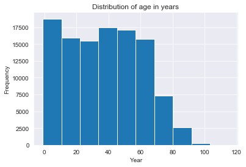

```python
# Examining the distribution of the age variable
dap.age.hist()
plt.title('Distribution of age in years')
plt.xlabel('Year')
plt.ylabel('Frequency')
```

> The age column consist of 1 neagtive number, many zeros, and some numbers greater than 100. Of course it is plausible that someone can be older than a century but such persons are rare and may have been suffering from undisclosed ailments that may make them book appointments when not needed or forget booked appointments. Moreover they may nop longer be in significant control of their movements and may not be able to force it. But can one really be -1 year old? This must be a mistake. I also ruminated on the idea of being 0 year old. Perhaps such persons are babies that are less than a year old. In such cases the appointments may have been made by their parents or foster parents or guardians. To get more insight on the distribution I plotted a histogram of the age and obseved that ages with members less than 10 are outliers. Such ages range from 98 to 115. So, I have decided to drop them too. Age as seen here is skewed to the right.

```python
# Dropping the ages greater than 97 and less than 0. I could have piped this to use only one code line
dap.drop(dap[dap['age'] > 97].index, inplace=True)
dap.drop(dap[dap['age'] < 0].index, inplace=True)
dap.age.value_counts()
```

```
0     3539
1     2273
52    1746
49    1652
53    1651
      ...
93      53
94      33
95      24
96      17
97      11
Name: age, Length: 98, dtype: int64
```

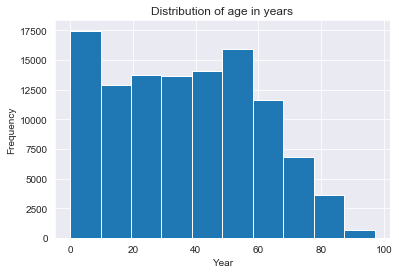

```python
# Checking the distribution again after dropping the unwanted ages.
dap.age.hist()
plt.title('Distribution of age in years')
plt.xlabel('Year')
plt.ylabel('Frequency')
```

```python
# Checking value counts
# Calling the function to check
checking()
```

[output not shown]

```python
# Dropping patientid and appointmentid variables
dap.drop(['patientid','appointmentid'], axis=1, inplace=True)
```

> You may have noticed that I keep checking the value_counts for the categorical variables. I am doing this to keep track of whether an operation I perform has an undesired change in them

```python
# Creating new columns
dap['delay_days'] = dap['appointmentday'] - dap['scheduledday']
```

```python
dap.head(2)
```

|  | patientid | appointmentid | gender | scheduledday | appointmentday | age | neighbourhood | scholarship | hipertension | diabetes | alcoholism | handcap | sms_received | no_show | delay_days |
| --- | --- | --- | --- | --- | --- | --- | --- | --- | --- | --- | --- | --- | --- | --- | --- |
| 0 | 2.987250e+13 | 5642903 | F | 2016-04-29 18:38:08 | 2016-04-29 | 62 | JARDIM DA PENHA | False | True | False | False | False | False | No | -1 days +05:21:52 |
| 1 | 5.589978e+14 | 5642503 | M | 2016-04-29 16:08:27 | 2016-04-29 | 56 | JARDIM DA PENHA | False | False | False | False | False | False | No | -1 days +07:51:33 |

```python
dap.no_show.value_counts()
```

```
No     88193
Yes    22315
Name: no_show, dtype: int64
```

```python
# This is the new dimension
dap.shape
```

```
(110508, 15)
```

```python
# Now we see the data types
dap.dtypes
```

```
patientid                 float64
appointmentid               int64
gender                     object
scheduledday       datetime64[ns]
appointmentday     datetime64[ns]
age                         int64
neighbourhood              object
scholarship                  bool
hipertension                 bool
diabetes                     bool
alcoholism                   bool
handcap                      bool
sms_received                 bool
no_show                    object
delay_days        timedelta64[ns]
dtype: object
```

> After much debate with myself and because I want to do some regressions with the dataset some other times, I decided to convert no_show to boolean. First I will convert it to 'int' using map() and then I will convert it to 'bool' using astype(). It should be noted that this no_show variable inverts the usual response order. If a patient shows up it is recorded as 'No' and if the patient doesn't show up a 'Yes' is recorded. It is in response to the question 'No show up for appointment?'. But the default value for boolean is false, hence, in this case a 'Yes' should be mapped to 0 and a 'No' to 1. Finally 'Yes' will translate to 'False' and 'No' to 'True'. This approach will help keep the sanity of the dataset. Now let's do it.

```python
# Converting string Yes and No to integer 0 and 1
dap['no_show'] = dap['no_show'].map({'No': 1, 'Yes': 0})
```

```python
# Converting the data type from int to bool
dap['no_show'] = dap['no_show'].astype(bool)
```

```python
# Checking to show if the change has been effected.
# Calling the function to check
checking()
```

```
The value counts for  scholarship variable in this dataset is:
False    99647
True     10861
Name: scholarship, dtype: int64
The value counts for  hipertension variable in this dataset is:
False    88715
True     21793
Name: hipertension, dtype: int64
The value counts for  diabetes variable in this dataset is:
False    102568
True       7940
Name: diabetes, dtype: int64
The value counts for  alcoholism variable in this dataset is:
False    107148
True       3360
Name: alcoholism, dtype: int64
The value counts for  handcap variable in this dataset is:
False    108273
True       2235
Name: handcap, dtype: int64
The value counts for  sms_received variable in this dataset is:
False    75030
True     35478
Name: sms_received, dtype: int64
The value counts for  no_show variable in this dataset is:
True     88193
False    22315
Name: no_show, dtype: int64
```

```python
# Checking the data types
dap.dtypes
```

```
patientid                 float64
appointmentid               int64
gender                     object
scheduledday       datetime64[ns]
appointmentday     datetime64[ns]
age                         int64
neighbourhood              object
scholarship                  bool
hipertension                 bool
diabetes                     bool
alcoholism                   bool
handcap                      bool
sms_received                 bool
no_show                      bool
delay_days        timedelta64[ns]
dtype: object
```

```python
# Now let us lok at gender
dap.gender.value_counts()
```

```
F    71824
M    38684
Name: gender, dtype: int64
```

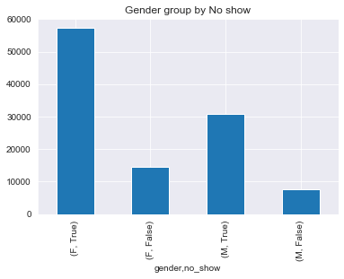

```python
# Let us see whether it will make sense to plot gender without converting to boolean
dap.groupby('gender')['no_show'].value_counts().plot(kind='bar')
plt.title('Gender group by No show')
```

```python
# Printing columns out
for i, v in enumerate(dap.columns):
    print(i,v)
```

```
0 patientid
1 appointmentid
2 gender
3 scheduledday
4 appointmentday
5 age
6 neighbourhood
7 scholarship
8 hipertension
9 diabetes
10 alcoholism
11 handcap
12 sms_received
13 no_show
14 delay_days
```

```python
# Saving cleaned data before moving to the next stage of this analysis
dap.to_csv('cleaned_noshow.csv', index=False)
```

## Exploratory Data Analysis

> At this stage I will explore the data using some visualizations. I will be considering bar chart and histograms where applicable. My observations will be discussed.

### How does each independent variable except the identification variables correlates with the dependent variable?

> First, let's start by visualizing each independent variable using histogram or bar chart.

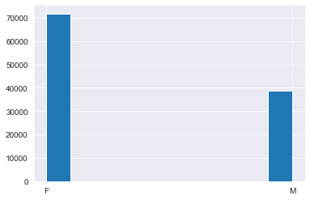

```python
#Plotting the histogram of gender
dap.gender.hist();
```

> The bar shows that more females book appointments than males. Let's look at the total number by gender.

```python
# Number of appointments per gender
dap.gender.value_counts()
```

```
F    71824
M    38684
Name: gender, dtype: int64
```

```python
# User defined function for comapring each variable to no_show
def plot_grp(groupby_col,title,figsize):
 print(dap.groupby(groupby_col)['no_show'].value_counts())
 dap.groupby(groupby_col)['no_show'].value_counts().plot(kind='bar', figsize=figsize)
 plt.title(title);
```

```
gender  no_show
F       True       57234
        False      14590
M       True       30959
        False       7725
Name: no_show, dtype: int64
```

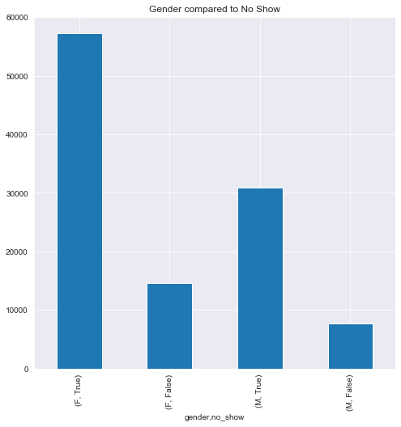

```python
# Let us see gender numbers and plots using the plot_grp function
plot_grp('gender','Gender compared to No Show',(8,8))
```

```python
#Percentages that show up
per1 = 57234/71824
per1
per2 = 30959/38684
per2
```

> From the counts, 33140 more females book appointment compared to males. Now how does this affect showing up for appointments?

```python
# Grouping no_show by delay_days. We will not plot the graph now because they are in timedeltas and we will still operate them
day_show = dap.groupby('delay_days')['no_show'].value_counts()
day_show.describe()
```

```
count    91709.000000
mean         1.204985
std          0.645681
min          1.000000
25%          1.000000
50%          1.000000
75%          1.000000
max         21.000000
Name: no_show, dtype: float64
```

```
sms_received  no_show
False         True       62499
              False      12531
True          True       25694
              False       9784
Name: no_show, dtype: int64
```

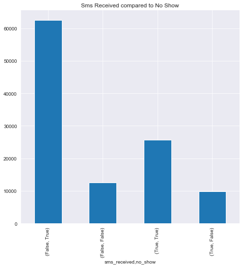

```python
# Let us see whether receiving an sms matters
plot_grp('sms_received','Sms Received compared to No Show',(8,8))
```

```
scholarship  no_show
False        True       79910
             False      19737
True         True        8283
             False       2578
Name: no_show, dtype: int64
```

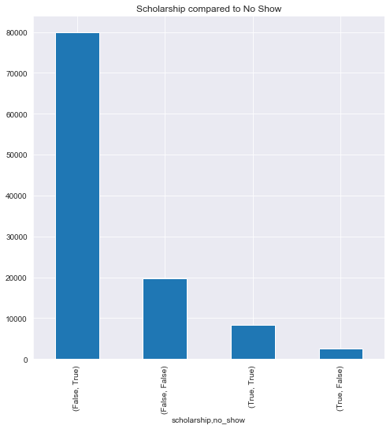

```python
# Examining how scholarship influences showing up
plot_grp('scholarship','Scholarship compared to No Show',(8,8))
```

```python
# Examining neighbourhood versus no_show
neigh = dap.groupby('neighbourhood')['no_show'].value_counts()
neigh.describe()
```

```
count     160.000000
mean      690.675000
std       897.743745
min         1.000000
25%       133.000000
50%       366.500000
75%       854.250000
max      6252.000000
Name: no_show, dtype: float64
```

```
neighbourhood    no_show
AEROPORTO        True          7
                 False         1
ANDORINHAS       True       1740
                 False       518
ANTÔNIO HONÓRIO  True        220
                            ...
TABUAZEIRO       False       573
UNIVERSITÁRIO    True        120
                 False        32
VILA RUBIM       True        710
                 False       141
Name: no_show, Length: 160, dtype: int64
```

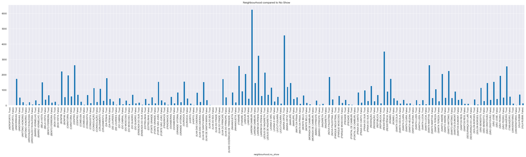

```python
# Now we see the individual numbers and plot the bar
plot_grp('neighbourhood','Neighbourhood compared to No Show',(40,8));
```

> While 75 percent of neighbourhoods are between 0 and 854, others have over 6000. From the jumbled chart, four neighbourhoods stood out. It, therefore, appears that some neighbourhood records more patient shows than others. We shall explore this further later. Let us move to age.

```python
# Exploring age
dap.groupby('age')['no_show'].value_counts()
```

```
age  no_show
0    True       2900
     False       639
1    True       1858
     False       415
2    True       1366
                ...
95   False         6
96   True         16
     False         1
97   True          9
     False         2
Name: no_show, Length: 196, dtype: int64
```

```python
# Let us first make age categorical
# So, we describe age to get the bean edges.
dap.age.describe()
```

```
count    110508.000000
mean         37.078374
std          23.096101
min           0.000000
25%          18.000000
50%          37.000000
75%          55.000000
max          97.000000
Name: age, dtype: float64
```

```python
# Next we create the age category column
bin_edges = [0, 18, 37, 55, 97]
bin_names = ['teen', 'youth', 'adult', 'old']
dap['age_category'] = pd.cut(dap['age'], bin_edges, labels=bin_names)
```

```python
# Now let us check the change
dap.tail()
dap.age_category.value_counts()
```

```
old      27486
youth    27250
adult    26906
teen     25327
Name: age_category, dtype: int64
```

> These age categories seem to have no significant difference in counts. The range is 2159 which translates to just 1.95 percent of the total number of appointments in the dataset. Next, we want to group them by no_show.

```
age_category  no_show
teen          True       19619
              False       5708
youth         True       20836
              False       6414
adult         True       21651
              False       5255
old           True       23187
              False       4299
Name: no_show, dtype: int64
```

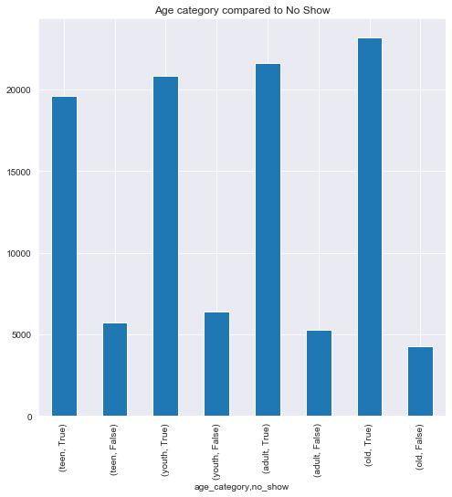

```python
# Grouping age_category by no_show
plot_grp('age_category','Age category compared to No Show',(8,8));
```

> From these counts and plot, it is seen that old category has the highest percentage of show up followed by the adult category, the teen category and the youth category (84.36%, 80.47%, 77.46%, 76.46% respectively). It appears that the older you are the better your chances of showing up on the appointment day. Patients older than 37 years appear to have better chances of showing up on appointment days than than younger ones. Perhaps such patients take their health more seriously. But we should also remember that some things may not show up due to their caretakers being busy. This msy also be true for some adults. Next, we examine handicap.

```
handcap  no_show
False    True       86362
         False      21911
True     True        1831
         False        404
Name: no_show, dtype: int64
```

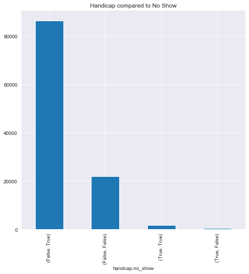

```python
# Examining handicap
plot_grp('handcap','Handicap compared to No Show',(8,8))
```

```
diabetes  no_show
False     True       81683
          False      20885
True      True        6510
          False       1430
Name: no_show, dtype: int64
```

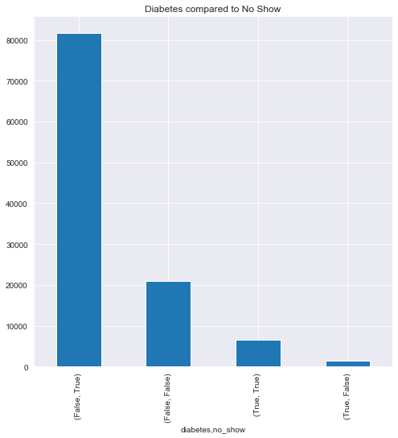

```python
# Examining diabetes
plot_grp('diabetes','Diabetes compared to No Show',(8,8));
```

> From the charts and counts it appears that being diabetic does not have any great effect on whether a patient shows up or not. 81.99 percent of the diabetic showed up whereas 79.64 percent of those without diabetes showed up. Just like handcap, slighty more diabetic patients show up compared to non-diabetic ones. Next, we look at alcoholism.

```
alcoholism  no_show
False       True       85510
            False      21638
True        True        2683
            False        677
Name: no_show, dtype: int64
```

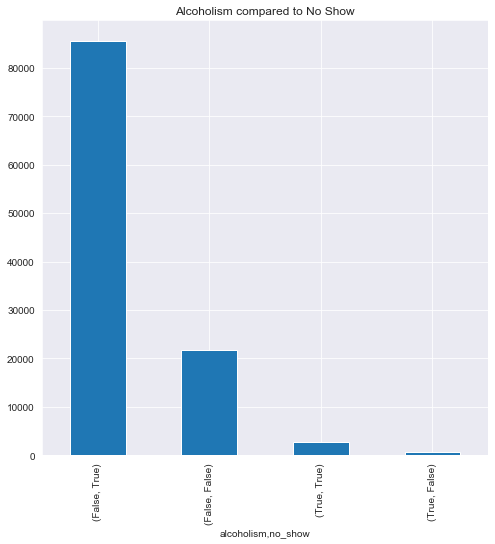

```python
# Examining whether alcoholism has effect on showing up
plot_grp('alcoholism','Alcoholism compared to No Show',(8,8));
```

> From the charts and counts it also appears that being an alcoholic does not have any effect on whether a patient shows up or not. 79.85 percent of the alcoholic showed up whereas 79.81 percent of the non-alcoholic showed up. It only slightly seems that alcoholics may remember to kkeep appointments than non-alcoholics. Next, we look at hypertension.

```
hipertension  no_show
False         True       70171
              False      18544
True          True       18022
              False       3771
Name: no_show, dtype: int64
```

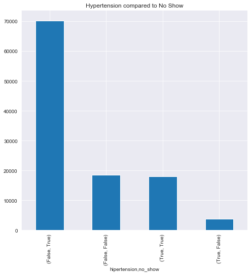

```python
# Examining hypertension
plot_grp('hipertension','Hypertension compared to No Show',(8,8))
```

> For the variable *hipertension* it appears that being an hypertensive patient only has slight effect on showing up. 82.70 percent of the hypertensive showed up whereas 79.10 percent of the non-hypertensive showed up. This condition appears to have higher percentage difference than the other condition variables (diabetes, alcoholism, and handicap). I will now move to the next research question.

### What factors are important to predict whether a patient will show up for their scheduled appointment?

> To answer this second question, I shall be working only on variables that have shown appreciable association with no_show. These are:
> - sms_received
> - age_category
> - scholarship
> - delay_days
> - neighbourhood
> - hipertension

> Now let us begin by partitioning the dataset into two namely those that showed (True = present) and those that didn't show (False = absent) on the appointment day.

```python
# Partitioning the dataset to show as present and no show as absent
present = dap.no_show == True
absent = dap.no_show == False
```

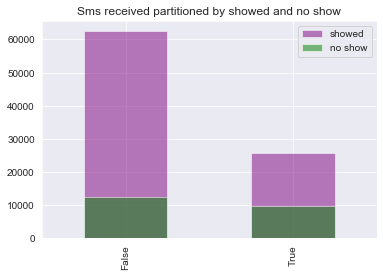

```python
# Now I will use these new partitions to look at each desired variable. I will start with sms_received
# Let us plot the bar for both partitions based on sms_received
dap.sms_received[present].value_counts().plot(kind='bar', alpha=0.5, color='purple', label='showed')
dap.sms_received[absent].value_counts().plot(kind='bar', alpha=0.5, color='green', label='no show')
plt.title('Sms received partitioned by showed and no show')
plt.legend();
```

```python
# Now we will look at the numbers
dap.sms_received[present].value_counts()
```

```
False    62499
True     25694
Name: sms_received, dtype: int64
```

```python
dap.sms_received[absent].value_counts()
```

```
False    12531
True      9784
Name: sms_received, dtype: int64
```

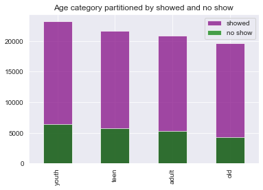

```python
# Let us plot the bar for both partitions based on age_category
dap.age_category[present].value_counts().plot(kind='bar', alpha=0.7, color='purple', label='showed')
dap.age_category[absent].value_counts().plot(kind='bar', alpha=0.7, color='green', label='no show')
plt.title('Age category partitioned by showed and no show')
plt.legend();
```

```python
# Now we look at the numbers.
dap.age_category[present].value_counts()
```

```
old      23187
adult    21651
youth    20836
teen     19619
Name: age_category, dtype: int64
```

```python
dap.age_category[absent].value_counts()
```

```
youth    6414
teen     5708
adult    5255
old      4299
Name: age_category, dtype: int64
```

> 50.84 percent of those present are older than 37 years but 54.32 percent of those absent are younger than 37 years. The youths are the group with the highest absent rate while the old category is the group with the highest present rate. So it appears, as earlier discussed that age is a useful variable in determining show or no show. Next, we look at scholarship.

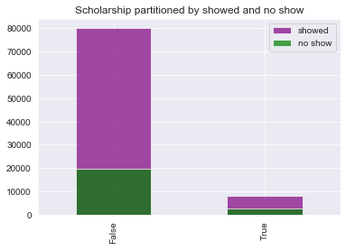

```python
# Let us plot the bar for both partitions based on scholarship
dap.scholarship[present].value_counts().plot(kind='bar', alpha=0.7, color='purple', label='showed')
dap.scholarship[absent].value_counts().plot(kind='bar', alpha=0.7, color='green', label='no show')
plt.title('Scholarship partitioned by showed and no show')
plt.legend();
```

```python
# Now we look at the numbers
dap.scholarship[present].value_counts()
```

```
False    79910
True      8283
Name: scholarship, dtype: int64
```

```python
dap.scholarship[absent].value_counts()
```

```
False    19737
True      2578
Name: scholarship, dtype: int64
```

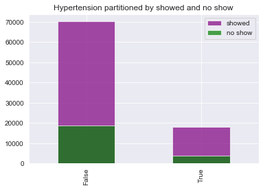

```python
# Let us plot the bar for both partitions based on hipertension
dap.hipertension[present].value_counts().plot(kind='bar', alpha=0.7, color='purple', label='showed')
dap.hipertension[absent].value_counts().plot(kind='bar', alpha=0.7, color='green', label='no show')
plt.title('Hypertension partitioned by showed and no show')
plt.legend();
```

```python
# Now we examine the numbers
dap.hipertension[present].value_counts()
```

```
False    70171
True     18022
Name: hipertension, dtype: int64
```

```python
dap.hipertension[absent].value_counts()
```

```
False    18544
True      3771
Name: hipertension, dtype: int64
```

> From the chart and the numbers, it appears that a greater proportion of hypertensive patients showed up comapred to the non-hypertensive ones. Perhaps appointments booked by hypertensive patients have a greater chance of resulting in a show. We will now look at neighbourhood.

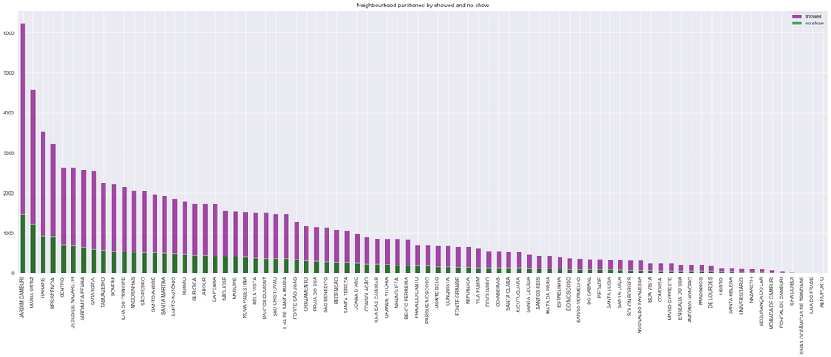

```python
# Let us plot the bar for both partitions based on neighbourhood
dap.neighbourhood[present].value_counts().plot(kind='bar', alpha=0.7, color='purple', label='showed', figsize=(30,10))
dap.neighbourhood[absent].value_counts().plot(kind='bar', alpha=0.7, color='green', label='no show', figsize=(30,10))
plt.title('Neighbourhood partitioned by showed and no show')
plt.legend()
plt.savefig("neighbourlarge.png");
```

```python
# Now shall we look at the numbers
dap.neighbourhood[present].value_counts()
```

```
JARDIM CAMBURI       6252
MARIA ORTIZ          4585
RESISTÊNCIA          3525
JARDIM DA PENHA      3246
SANTA MARTHA         2634
                     ...
PONTAL DE CAMBURI      57
ILHA DO BOI            32
ILHA DO FRADE           8
AEROPORTO               7
PARQUE INDUSTRIAL       1
Name: neighbourhood, Length: 80, dtype: int64
```

```python
dap.neighbourhood[absent].value_counts()
```

```
JARDIM CAMBURI                 1465
MARIA ORTIZ                    1219
ITARARÉ                         923
RESISTÊNCIA                     906
CENTRO                          703
                               ...
PONTAL DE CAMBURI                12
ILHA DO BOI                       3
ILHAS OCEÂNICAS DE TRINDADE       2
ILHA DO FRADE                     2
AEROPORTO                         1
Name: neighbourhood, Length: 80, dtype: int64
```

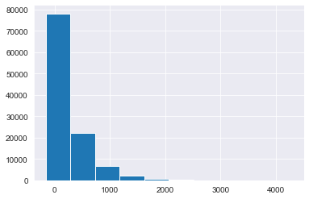

```python
# Let us see the distribution for delay_days. To do this we need to convert the timedeltas to hours( I choose hours).
dap['delay_days'].astype('timedelta64[h]').hist()
```

> This is skewed to the right. It means the closer the scheduledday to the appointment day, the greater the chances of the patient showing up. This seems a strong factor. But let us explore it more.

```python
# Next we put this hour based delay_days in a variable
hours = dap['delay_days'].astype('timedelta64[h]')
```

```python
# Now we add hours to our data frame
dap['hours'] = hours
```

```python
dap.head()
```

|  | patientid | appointmentid | gender | scheduledday | appointmentday | age | neighbourhood | scholarship | hipertension | diabetes | alcoholism | handcap | sms_received | no_show | delay_days | age_category | hours |
| --- | --- | --- | --- | --- | --- | --- | --- | --- | --- | --- | --- | --- | --- | --- | --- | --- | --- |
| 0 | 2.987250e+13 | 5642903 | F | 2016-04-29 18:38:08 | 2016-04-29 | 62 | JARDIM DA PENHA | False | True | False | False | False | False | True | -1 days +05:21:52 | old | -19.0 |
| 1 | 5.589978e+14 | 5642503 | M | 2016-04-29 16:08:27 | 2016-04-29 | 56 | JARDIM DA PENHA | False | False | False | False | False | False | True | -1 days +07:51:33 | old | -17.0 |
| 2 | 4.262962e+12 | 5642549 | F | 2016-04-29 16:19:04 | 2016-04-29 | 62 | MATA DA PRAIA | False | False | False | False | False | False | True | -1 days +07:40:56 | old | -17.0 |
| 3 | 8.679512e+11 | 5642828 | F | 2016-04-29 17:29:31 | 2016-04-29 | 8 | PONTAL DE CAMBURI | False | False | False | False | False | False | True | -1 days +06:30:29 | teen | -18.0 |
| 4 | 8.841186e+12 | 5642494 | F | 2016-04-29 16:07:23 | 2016-04-29 | 56 | JARDIM DA PENHA | False | True | True | False | False | False | True | -1 days +07:52:37 | old | -17.0 |

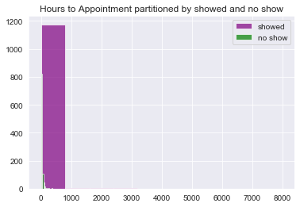

```python
# Let us plot the histogram for both partitions based on hours
dap.hours[present].value_counts().hist(alpha=0.7, color='purple', label='showed')
dap.hours[absent].value_counts().hist(alpha=0.7, color='green', label='no show')
plt.title('Hours to Appointment partitioned by showed and no show')
plt.legend()
plt.savefig("hours.png");
```

> It is seen that almost all schedules close to the appointment day resulted in a show. Let us create an hour category for better visualization.

```python
# Getting the bin_edges
dap.hours.describe()
```

```
count    110508.000000
mean        232.615593
std         365.830112
min        -158.000000
25%          -9.000000
50%          83.000000
75%         343.000000
max        4285.000000
Name: hours, dtype: float64
```

```python
# Creating the hour_category variable
bin_edges = [-158, -9, 83, 343, 4285]
bin_names = ['very-close', 'mod-close', 'close', 'far']
dap['hour_category'] = pd.cut(dap['hours'], bin_edges, labels=bin_names)
dap.head()
```

|  | patientid | appointmentid | gender | scheduledday | appointmentday | age | neighbourhood | scholarship | hipertension | diabetes | alcoholism | handcap | sms_received | no_show | delay_days | age_category | hours | hour_category |
| --- | --- | --- | --- | --- | --- | --- | --- | --- | --- | --- | --- | --- | --- | --- | --- | --- | --- | --- |
| 0 | 2.987250e+13 | 5642903 | F | 2016-04-29 18:38:08 | 2016-04-29 | 62 | JARDIM DA PENHA | False | True | False | False | False | False | True | -1 days +05:21:52 | old | -19.0 | very-close |
| 1 | 5.589978e+14 | 5642503 | M | 2016-04-29 16:08:27 | 2016-04-29 | 56 | JARDIM DA PENHA | False | False | False | False | False | False | True | -1 days +07:51:33 | old | -17.0 | very-close |
| 2 | 4.262962e+12 | 5642549 | F | 2016-04-29 16:19:04 | 2016-04-29 | 62 | MATA DA PRAIA | False | False | False | False | False | False | True | -1 days +07:40:56 | old | -17.0 | very-close |
| 3 | 8.679512e+11 | 5642828 | F | 2016-04-29 17:29:31 | 2016-04-29 | 8 | PONTAL DE CAMBURI | False | False | False | False | False | False | True | -1 days +06:30:29 | teen | -18.0 | very-close |
| 4 | 8.841186e+12 | 5642494 | F | 2016-04-29 16:07:23 | 2016-04-29 | 56 | JARDIM DA PENHA | False | True | True | False | False | False | True | -1 days +07:52:37 | old | -17.0 | very-close |

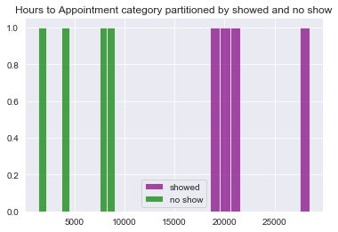

```python
# Visualizing the hour category
dap.hour_category[present].value_counts().hist(alpha=0.7, color='purple', label='showed')
dap.hour_category[absent].value_counts().hist(alpha=0.7, color='green', label='no show')
plt.title('Hours to Appointment category partitioned by showed and no show')
plt.legend()
plt.savefig("hours_cat.png");
```

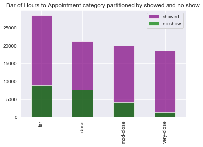

```python
# Visualizing the hour category
dap.hour_category[present].value_counts().plot(kind='bar', alpha=0.7, color='purple', label='showed')
dap.hour_category[absent].value_counts().plot(kind='bar', alpha=0.7, color='green', label='no show')
plt.title('Bar of Hours to Appointment category partitioned by showed and no show')
plt.legend()
plt.savefig("hours_barcat.png");
```

```python
# Let us see some numbers
dap.hour_category[present].value_counts()
```

```
very-close    28473
mod-close     21210
close         19942
far           18568
Name: hour_category, dtype: int64
```

```python
dap.hour_category[absent].value_counts()
```

```
far           9020
close         7651
mod-close     4226
very-close    1417
Name: hour_category, dtype: int64
```

> From these histograms and bars, it is clear that most patients that show has a delay day of not greater than 343 hours which is approximately 2 weeks. Interestingly a greater proportion of shows occur with appointments with delay days of less than 4 days (83 hours). 74.71 percent of no shows (absent) is attributable to delay_days of greater than 4 days. Hence, delay_days is a strong factor in determining appointment shows. Finally let us look at gender again.

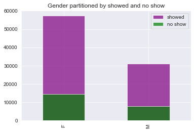

```python
#Let us look at the bar chart for gender
dap.gender[present].value_counts().plot(kind='bar', alpha=0.7, color='purple', label='showed')
dap.gender[absent].value_counts().plot(kind='bar', alpha=0.7, color='green', label='no show')
plt.title('Gender partitioned by showed and no show')
plt.legend()
plt.savefig("gender.png");
```

```python
# Let us see the numbers
dap.gender[present].value_counts()
```

```
F    57234
M    30959
Name: gender, dtype: int64
```

```python
dap.gender[absent].value_counts()
```

```
F    14590
M     7725
Name: gender, dtype: int64
```

```python
# I want to save my final cleaned no-show-appointments dataset
dap.to_csv('final_show.csv', index=False)
```

> A greater proportion of appointments scheduled by males resulted in a show compared to those booked by females. This is interesting because more females book appointments than males.

> At this point, I want to say I have finished the exploration of the data. The next section draws the conclusion.

### Conclusions

> Conclusively, the following factors appears to be important in determining whether a patient show on the appointment day or not. They are:
> - neighbourhood
> - age (that is age_category)
> - hipertension
> - sms_received
> - scholarship
> - delay_days (that is hour_category
> - gender

### Limitations

> The dataset is massive but has more appointments from some regions. In some of these regions, a great percentage failed to show up. I think it will be better if the dataset is expanded to include more appointments from other regions. Perhaps all appointments in a district or administrative region for a specified period of time should be documented and analyzed in order to be sure of the influence of neighbourhood. An alternative I could have explored is to group some neighbourhoods together but I don't know much about each neighbourhood to warrant this.

> Second, some appointments have the age zero. I want to believe this is not a mistake but it could be. If it is a mistake then those columns should have been dropped. If they are dropped, I believe it will have an impact on this analysis. Such impacts may negate some of the findings here.

> Lastly, my skills are still rudimentary and perhaps when I become much better I may be able to analyze this dataset much more better.

> Please note that most of the variables in this dataset are categorical and as a result will benefit more from a logistic regression analysis in order to draw inferences and make predictions. Unfortunately, I cannot perform such analysis now using the tools available to me. Thanks for staying through the whole analysis process, though long. **The first review was very helpful and enlightening. Thanks so much.** I look forward to the second review.